# Pilot results - July 2024

#### Summary

- decreasing the global amount of signal in a trial (Figure 7A):
  - generally decreases accuracy
  - slightly decreases RTs on incongruent trials
  - does not appear to affect confidence
- increasing the first noise duration (Figure 7B):
  - does not appear to exert substantive changes on behavior
- increasing the second noise duration (Figure 7C):
  - maybe decreases accuracy on incongruent trials?
  - speeds incongruent RTs until it doesnt (4th quartile)
  - maybe increases confidence for incongruent trials until it doesn’t (4th quartile)
  - maybe decreases confidence for neutral trials until it doesn’t (4th quartile)

### Part 3: Behavior averaged over total time in the experiment

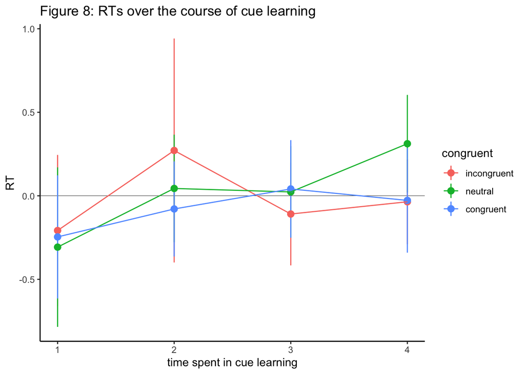

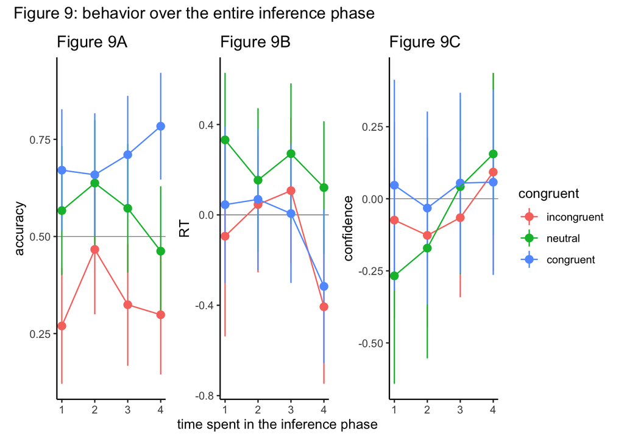

#### Summary

- Figure 8: as people progress through the cue learning phase, they get slower at responding to targets that follow a neutral cue
- Figure 9: as people gain more experience performing the cued inference task,
  - Fig 9A: they become more accurate on congruent trials and less accurate on neutral trials
  - Fig 9B: they respond faster only on trials with non-neutral cues
  - Fig 9C: they get more confident in general, but especially for decisions made with neutral cues
- comparing 9A and 9C suggests that, at a coarse level, metacognitive sensitivity in the neutral condition *decreases* over the course of the experiment: participants’ accuracy decreases but confidence increases, despite RTs staying the same. so their discrimination is getting worse, their RTs aren’t necessarily signaling better performance, but they’re still more confident than they were at the start. to be fair, this seems like it’s mainly driven by really low confidence in the first half of inference. but it’s still worth noting given the opposing trend in performance!